# SocialDistanceModel

Enrico Guerriero

(entro) Settembre 2023

### Analisi dei microdati del 2020 della Banca d’Italia

L’analisi che segue prevede la creazione di un modello efficiente in grado di stimare i consumi delle famiglie durante l’anno 2020. Si ricerca la costruzione di un modello spaziale, basato sulle interazioni tra le osservazioni in funzione della loro distanza: in particolare, non si tratteranno distanza fisiche ma si ricercherà una “distanza sociale”: questa verrà definita come distanza euclidea (ma seguiranno tentativi anche con distanze di Manhattan e Gower) nel sottospazio vettoriale generato da alcune colonne del dataset. Cruciale per il modello sarà quindi la scelta delle colonne che verranno poi utilizzati per costruire tale distanza.

Il database utilizzato è quello fornito dalla Banca d’Italia (https://www.bancaditalia.it/statistiche/tematiche/indagini-famiglie-imprese/bilanci-famiglie/distribuzione-microdati/ricerca/ricerca.html?min_anno_pubblicazione=2023&max_anno_pubblicazione=2023).

## Il dataset

I dati forniti non sono racchiusi in un unico dataset, ma al contrario sono distribuiti in più tabelle, dalle quali è stata fatta una selezione: si è scelto di operare con le tabelle Q20A, Q20B, Q20C1, Q20C2, Q20D, Q20E, Q20F e Q20G, contenenti le risposte di ciascuna famiglia ai questionari familiari, e aventi come chiave primaria la variabile NQUEST (Numero di questionario); è stata utilizzata anche un’ultima tabella, la tabella carcom20, contenente le risposte di tutti gli individui di ciascuna famiglia al questionario individuale, avente come chiavi primarie NQUEST e NORD (Numero d’ordine del componente all’interno della famiglia).

Alle tabelle sono state applicate aggregazioni e trasformazioni, al fine di ottenere un’unica tabella con le variabili di interesse per lo studio, aventi tutte come unità di riferimento la famiglia:

- NQUEST: Numero di questionario, è stata mantenuta solo perché chiave primaria anche di questa tabella.
- NCOMP: Numero di componenti della famiglia.
- VALOGG: Valore degli oggetti di valore della famiglia.
- VALCAR: Valore delle macchine della famiglia.
- VALMEZ: Valore degli altri mezzi della famiglia.
- VALCA: Valore degli oggetti “della casa” della famiglia (es. elettrodomestici).
- CIBINT: Valore del cibo consumato in casa al mese.
- CIBEST: Valore del cibo consumato fuori casa al mese.
- BOLLETTE: Valore medio mensile delle bollette.
- VIAGGI: Valore dei viaggi effettuati nel 2020.
- ALTCONS: Valore degli altri consumi (non rientranti nelle precedenti categorie) effettuati nel 2020.
- SOLDMENS: Cifra mensile necessaria per una vita dignitosa senza lussi per la propria famiglia.
- FINMES: Facilità ad arrivare a fine mese (1 molta difficoltà, 6 molta facilità).
- HAPPY: Felicità dell’intervistato (1 molto triste, 10 molto felice). Questa variabile fa riferimento ad un solo componente della famiglia.
- HOMEVAL: Valore dell’abitazione in cui vive la famiglia.
- REDPERC: Quanto la famiglia ritiene che il proprio reddito si discosti dalla media.
- REDPERCFINE: Quanto la famiglia ritiene che il proprio reddito varierà nell’anno seguente.
- VAROGG: Variazione di valore degli oggetti di valore della famiglia nel 2020.
- VARCAR: Variazione di valore delle macchine della famiglia nel 2020.
- VARMEZ: Variazione di valore degli altri mezzi della famiglia nel 2020.
- VARCA: Variazione di valore degli oggetti della casa della famiglia nel 2020.
- VARCON: Variazione dei consumi della famiglia nel 2020.
- VARCONAL: Variazione dei consumi alimentari della famiglia nel 2020.
- SEX: Proporzione di maschi nella famiglia.
- STUDIO: Il titolo di studio maggiore conseguito tra i membri della famiglia (da 1 a 8, ordinata).
- OCC: Numero di occupati nella famiglia.
- DIP: Numero di lavoratori dipendenti nella famiglia.
- IND: Numero di lavoratori indipendenti nella famiglia.
- DIS: Numero di disoccupati nella famiglia.
- PENS: Numero di pensionati nella famiglia.
- VALUX: Valore totale degli oggetti di lusso.
- PROLAV: Proporzione di lavoratori nella famiglia.
- PROCIB: Proporzione di cibo consumato fuori casa.
- PRORED: Proporzione di componenti che percepiscono un reddito.

Summary del dataset:

```
##      NQUEST           NCOMP           VALOGG            VALCAR
##  Min.   :   173   Min.   :1.000   Min.   :      0   Min.   :      0
##  1st Qu.:893548   1st Qu.:2.000   1st Qu.:    600   1st Qu.:   1500
##  Median :931181   Median :2.000   Median :   2000   Median :   6000
##  Mean   :876131   Mean   :2.433   Mean   :  11926   Mean   :  11584
##  3rd Qu.:948236   3rd Qu.:3.000   3rd Qu.:   6000   3rd Qu.:  15000
##  Max.   :975477   Max.   :9.000   Max.   :3000000   Max.   :1000000
##      VALMEZ            VALCA            CIBINT         CIBEST
##  Min.   :      0   Min.   :    50   Min.   :  50   Min.   :   0.0
##  1st Qu.:      0   1st Qu.:  4000   1st Qu.: 300   1st Qu.:   0.0
##  Median :      0   Median : 10000   Median : 500   Median :  50.0
##  Mean   :   2193   Mean   : 14131   Mean   : 526   Mean   : 121.1
##  3rd Qu.:    300   3rd Qu.: 18000   3rd Qu.: 600   3rd Qu.: 150.0
##  Max.   :2500000   Max.   :800000   Max.   :5000   Max.   :5000.0
##     BOLLETTE         VIAGGI         ALTCONS           SOLDMENS
##  Min.   :    0   Min.   :    0   Min.   :    0.0   Min.   :  100
##  1st Qu.: 1800   1st Qu.:    0   1st Qu.:  200.0   1st Qu.: 1700
##  Median : 2500   Median :    0   Median :  350.0   Median : 2500
##  Mean   : 3115   Mean   :  808   Mean   :  603.8   Mean   : 2852
##  3rd Qu.: 4000   3rd Qu.: 1000   3rd Qu.:  600.0   3rd Qu.: 3500
##  Max.   :50000   Max.   :40000   Max.   :30000.0   Max.   :30000
##      FINMES          HAPPY          HOMEVAL           REDPERC
##  Min.   :1.000   Min.   : 1.00   Min.   :   5000   Min.   :-1000000
##  1st Qu.:3.000   1st Qu.: 7.00   1st Qu.: 120000   1st Qu.:       0
##  Median :4.000   Median : 8.00   Median : 196000   Median :       0
##  Mean   :3.577   Mean   : 7.45   Mean   : 272816   Mean   :   -2008
##  3rd Qu.:4.000   3rd Qu.: 8.00   3rd Qu.: 300000   3rd Qu.:       0
##  Max.   :6.000   Max.   :10.00   Max.   :5000000   Max.   :  400000
##   REDPERCFINE             VAROGG             VARCAR           VARMEZ
##  Min.   :-1000000.0   Min.   :-30000.0   Min.   :-12000   Min.   :-10000.0
##  1st Qu.:       0.0   1st Qu.:     0.0   1st Qu.:     0   1st Qu.:     0.0
##  Median :       0.0   Median :     0.0   Median :     0   Median :     0.0
##  Mean   :    -849.8   Mean   :   275.8   Mean   :  1100   Mean   :   124.7
##  3rd Qu.:       0.0   3rd Qu.:     0.0   3rd Qu.:     0   3rd Qu.:     0.0
##  Max.   : 1000000.0   Max.   :200000.0   Max.   :180000   Max.   :145000.0
##      VARCA             VARCON             VARCONAL              SEX
##  Min.   :    0.0   Min.   :-16000.00   Min.   :-4000.000   Min.   :0.0000
##  1st Qu.:    0.0   1st Qu.:     0.00   1st Qu.:    0.000   1st Qu.:0.3333
##  Median :    0.0   Median :     0.00   Median :    0.000   Median :0.5000
##  Mean   :  490.8   Mean   :   -51.03   Mean   :   -2.851   Mean   :0.4900
```

[output cut: 8 more lines]

```
##  Max.   :8.000   Max.   :6.0000   Max.   :5.0000   Max.   :5.0000
##       DIS              PENS            VALUX            CONSUMO
##  Min.   :0.0000   Min.   :0.0000   Min.   :     50   Min.   :  120
##  1st Qu.:0.0000   1st Qu.:0.0000   1st Qu.:  10000   1st Qu.: 2700
##  Median :0.0000   Median :0.0000   Median :  21002   Median : 4075
##  Mean   :0.8509   Mean   :0.6474   Mean   :  39834   Mean   : 5174
##  3rd Qu.:1.0000   3rd Qu.:1.0000   3rd Qu.:  41688   3rd Qu.: 6150
##  Max.   :6.0000   Max.   :3.0000   Max.   :4200000   Max.   :88000
##      PROLAV           PROCIB           PRORED
##  Min.   :0.0000   Min.   :0.0000   Min.   :0.0000
##  1st Qu.:0.0000   1st Qu.:0.0000   1st Qu.:0.5000
##  Median :0.3333   Median :0.1176   Median :1.0000
##  Mean   :0.3642   Mean   :0.1481   Mean   :0.7323
##  3rd Qu.:0.6667   3rd Qu.:0.2500   3rd Qu.:1.0000
##  Max.   :1.0000   Max.   :0.9091   Max.   :1.0000
```

Il dataframe conta 6239 osservazioni, tuttavia 141 famiglie non hanno risposto ad almeno una domanda. Per il momento vado a creare un nuovo dataframe con le 6098 osservazioni complete, poi si potrà fare una valutazione sulle osservazioni mancanti.

```r
df <-  myframe[complete.cases(myframe), ]
```

## Analisi Descrittiva del Dataset

Prima della costruzione dei modelli si procede con una breve analisi esplorativa dei dati, al fine di avere una visione più chiara sul fenomeno da studiare.

### Analisi Univariata

Si visualizzano le frequenze delle variabili discrete:

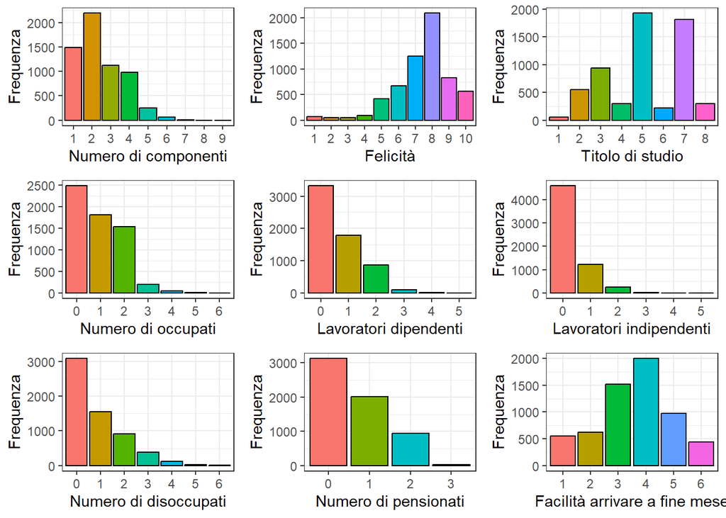

Adesso si visualizzano le variabili continue; le seguenti variabili hanno distribuzioni molto asimmetriche, pertanto a sinistra si vedono i grafici indicanti la distribuzione effettiva, a destra quelli con la distribuzione priva degli ultimi 5 percentili:

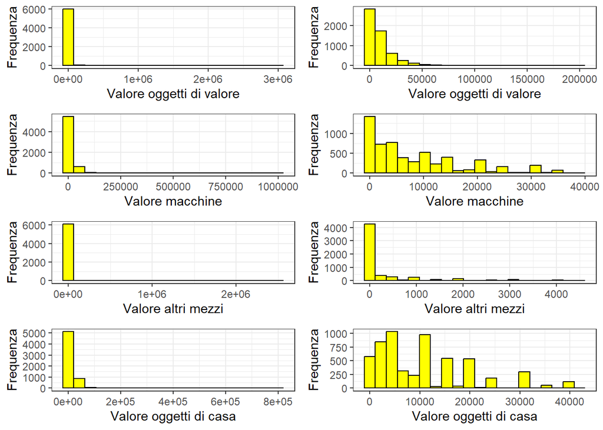

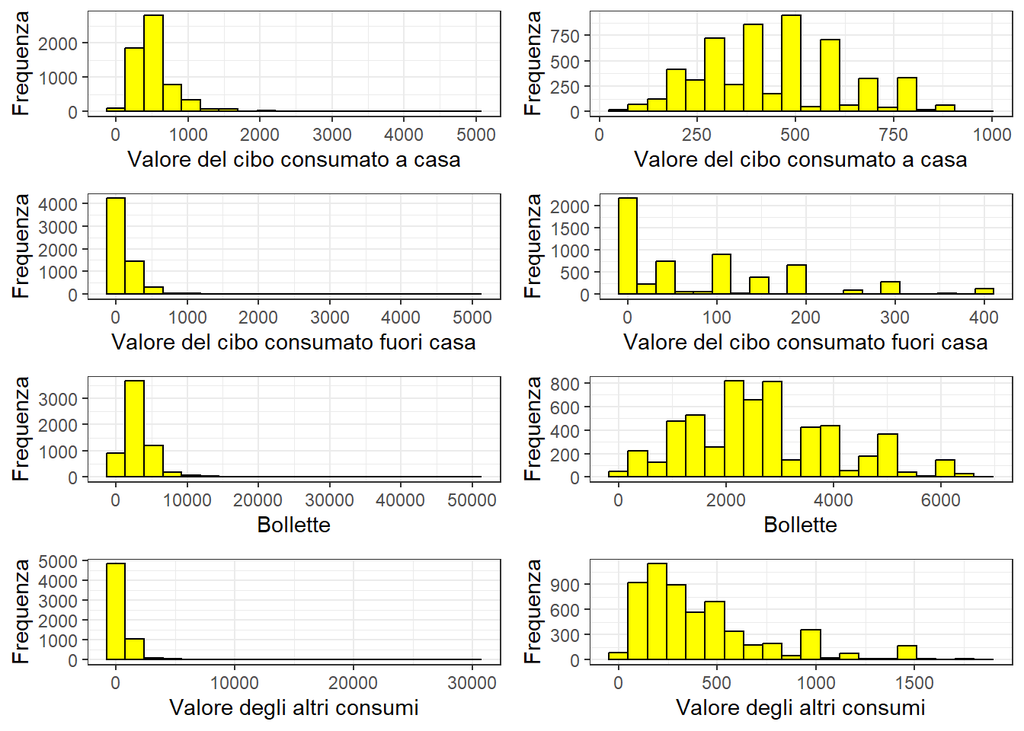

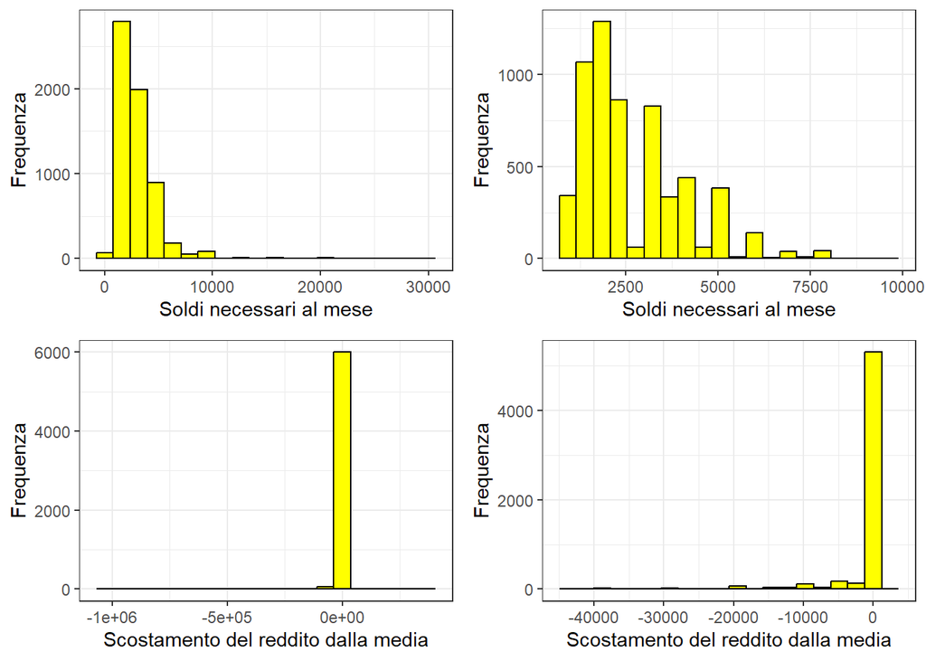

Seguono dei grafici “brutti” ma che non possono essere corretti togliendo quantili in quanto la maggiorparte dei dati si concentra su una risposta:

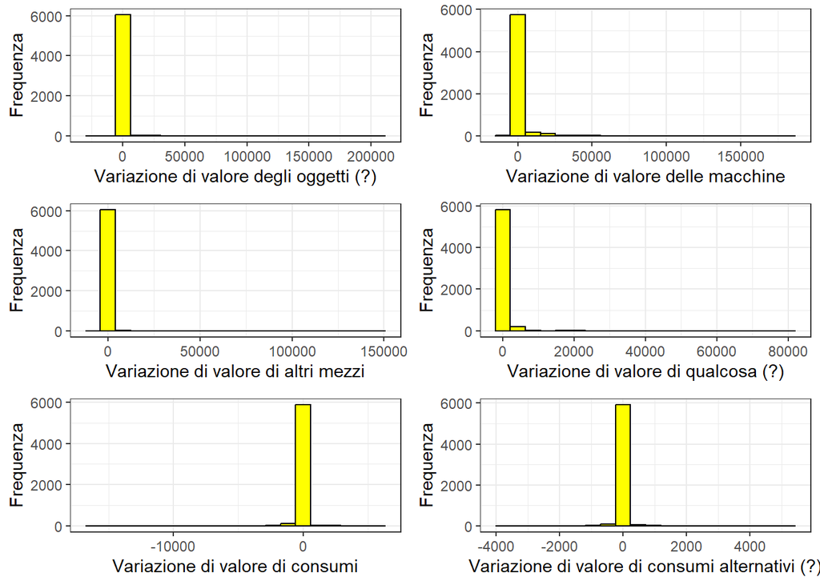

Per quanto riguarda i viaggi e il valore dei beni di lusso, è sufficiente togliere un percentile per stabilizzare la scala sull’asse x:

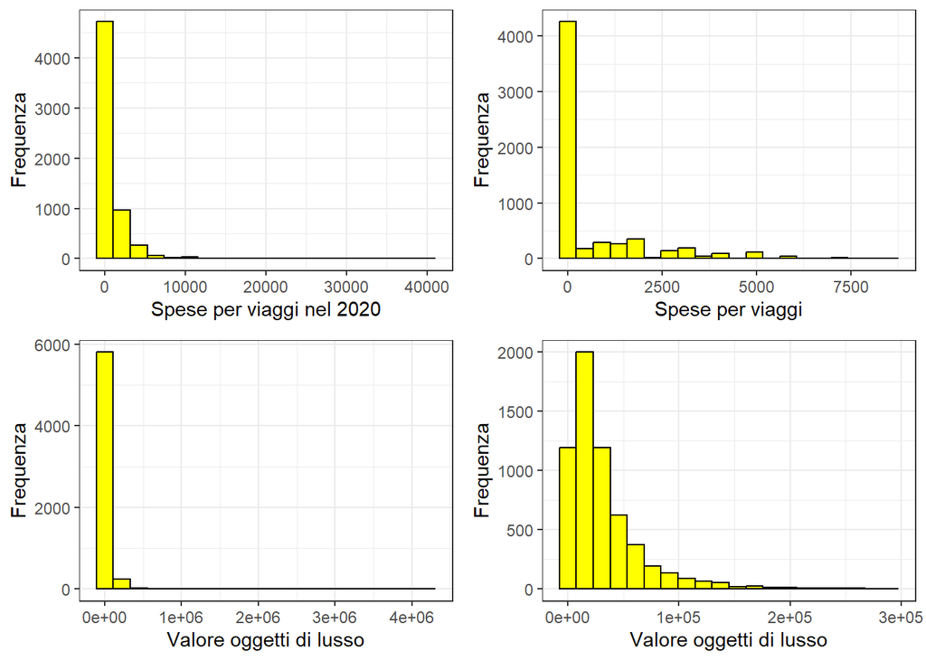

I seguenti grafici possono essere rappresentati per le intere distribuzioni:

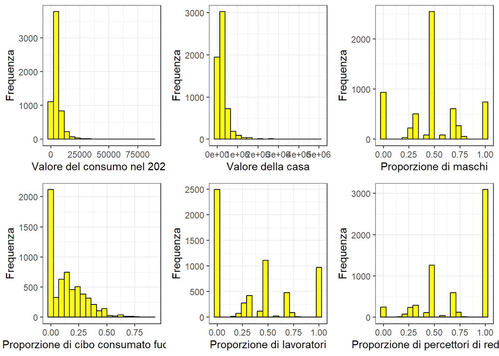

### Analisi Multivariata

Analisi mirata a vedere il comportamento delle variabili in relazione alla variabile CONSUMO, variabile risposta per questo studio, e tra loro, in vista della definizione di una distanza.

Si parte con la visualizzazione del correlogramma:

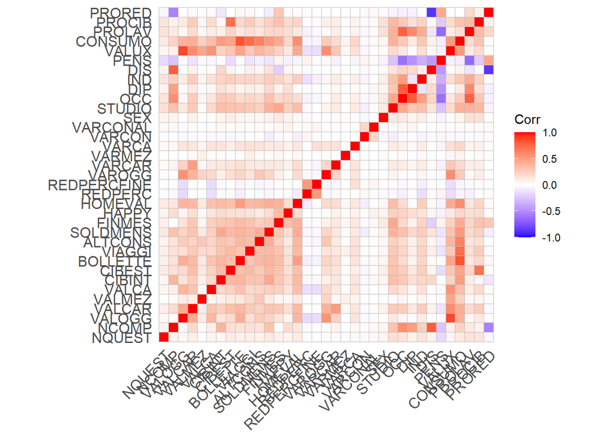

C’è un evidente problema di sovrabbondanza di variabili, per visualizzare più facilmente le correlazioni il dataset viene diviso in sottoinsiemi, ciascuno contenente la variabile consumo poiché siamo interessati principalmente a lei:

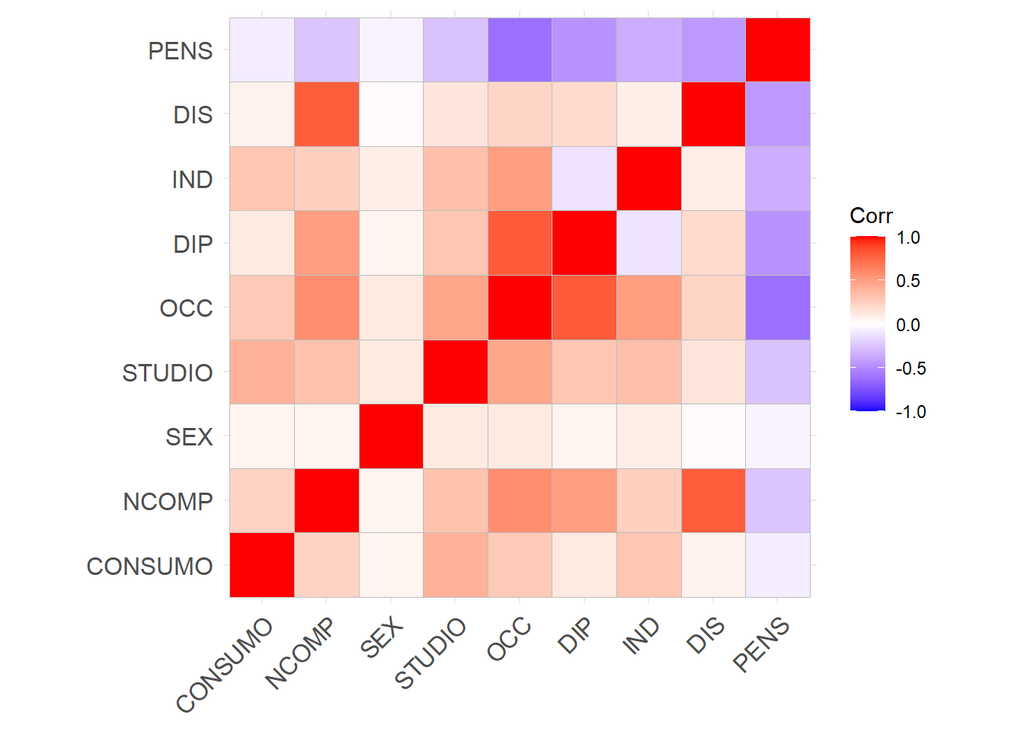

```
##          NCOMP       SEX    STUDIO       OCC       DIP       IND        DIS
## [1,] 0.2283554 0.0627067 0.3961633 0.2782143 0.1137242 0.2963853 0.07407471
##             PENS
## [1,] -0.08418292
```

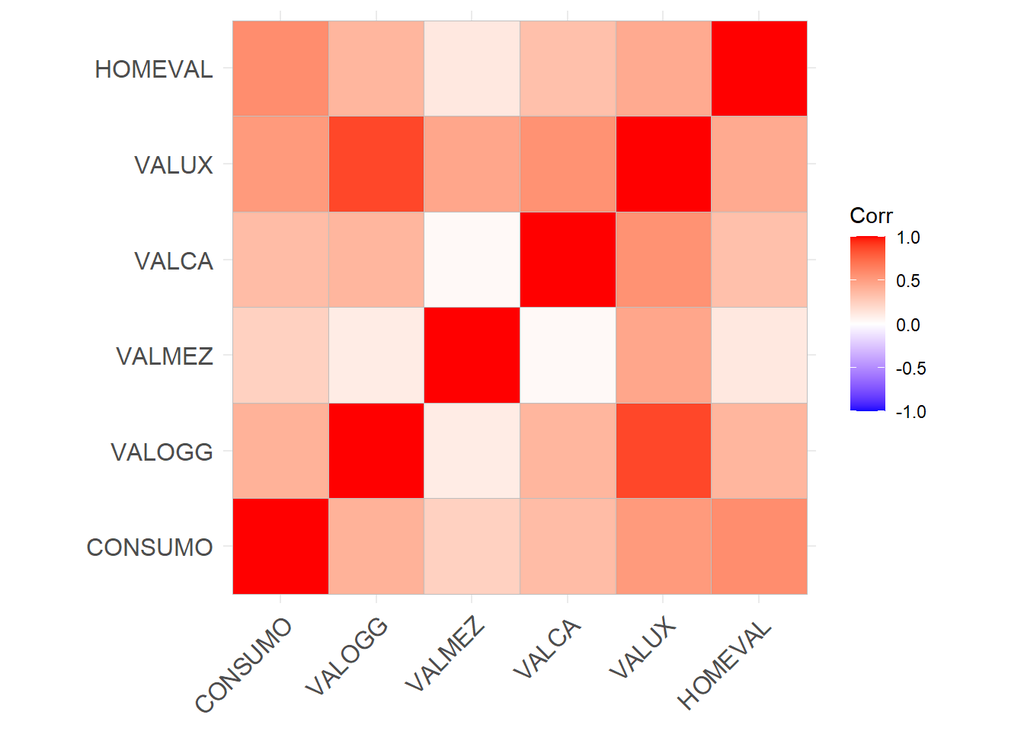

```
##         VALOGG    VALMEZ     VALCA     VALUX   HOMEVAL
## [1,] 0.3972919 0.2369291 0.3496423 0.5154401 0.5800499
```

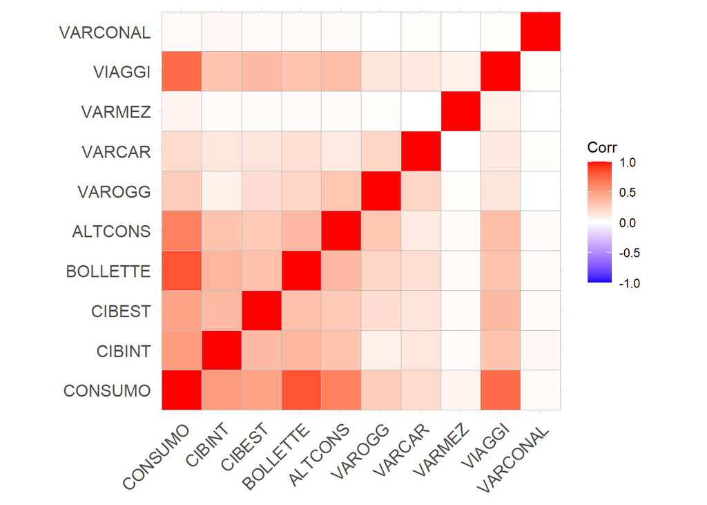

```
##         CIBINT   CIBEST  BOLLETTE   ALTCONS    VAROGG    VARCAR     VARMEZ
## [1,] 0.5139284 0.482167 0.8288102 0.6369341 0.2673356 0.1895297 0.05504021
##         VIAGGI   VARCONAL
## [1,] 0.7345408 0.02799145
```

Seguono tutti gli scatterplot tra la variabile consumo e ciascuna esplicativa:

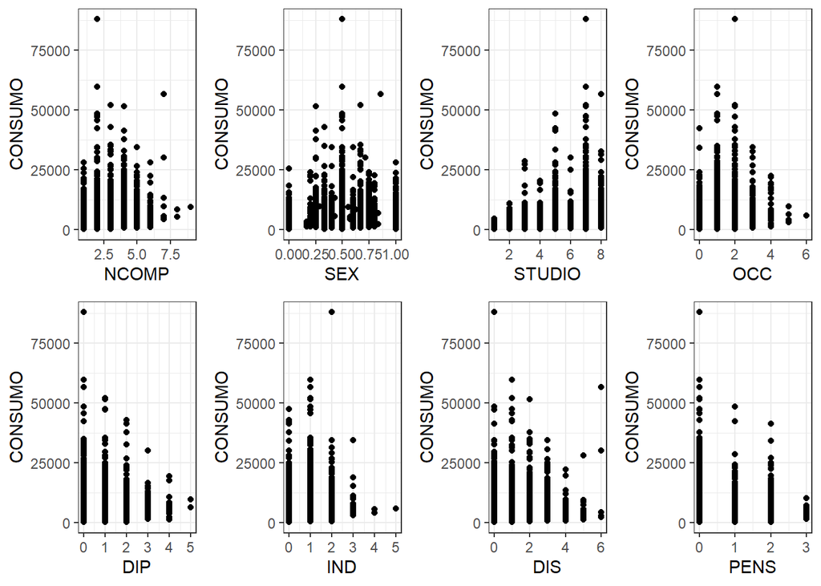

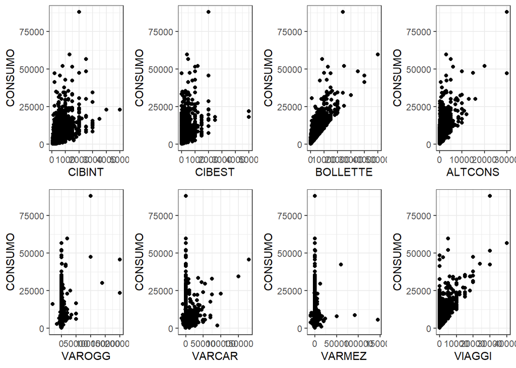

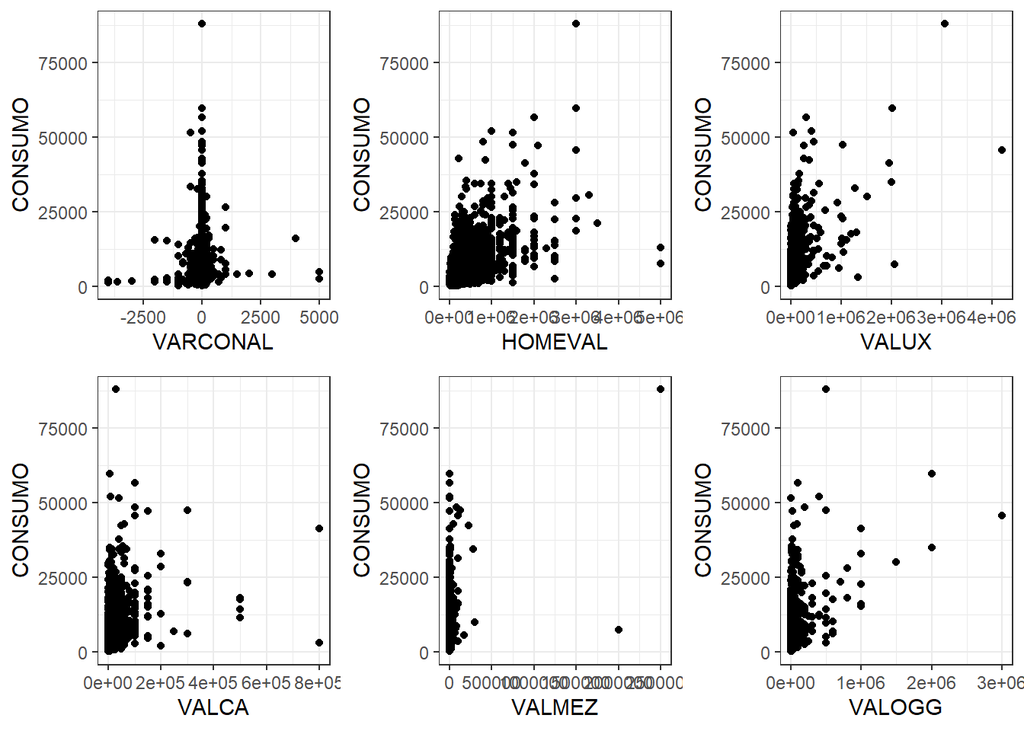